# varroa_modules

Nurit

4/13/2020

this analysis is on the 66 libraries (i removed the 5 outlirered libraries from the “data/kallisto” folder in GitHub, however they still exsist in the local folder: “/Users/nuriteliash/OneDrive - OIST/Repos/varroa-virus-networks-Local/data/kallisto.rds”. the working directory is in GitHb: “/Users/nuriteliash/Documents/GitHub/varroa-virus-networks”

I save all the big outputs results in my local storage, on OneDrive: “/Users/nuriteliash/OneDrive - OIST/Repos/varroa-virus-networks-Local/results”

NOTE: before runing this rmd, first run “varroa virus networks.Rmd” to get the virus data.

```r
library("dplyr")
library("tidyverse")
library("vegan")
library("DESeq2")
library("ggfortify")
library("WGCNA")
library("rmarkdown")
library("knitr") # for the markdown
library("kableExtra") # for creating a scrolling table
library("ggplot2") # for plotting
library("ape") # for reading the phylogenetic tree and for mantel.test
library("Biostrings")
library("ggtree") # for plotting the tree
library("ggrepel") # for spreading text labels on the plot
library("scales") # for axis labels notation
library("GO.db")
library("reshape2")
library("RSQLite")
library("AnnotationDbi")
library("GSEABase")
library("GOstats")
library("maps") # for the map background
library("leaflet") #for the interactive maps
library("htmltools")
library("rgdal")
library("grid")
library("gridExtra")
library("GeneOverlap")
library("cluster")
```

### import and join varroa data

```r
#import the varroa transcripts ("target_id") and their corresponding gene ("gene_id"). and add a col names.
varroa_isoforms <- read_tsv("/Users/nuriteliash/Documents/GitHub/varroa-virus-networks/data/gene2isoform.txt.gz", col_names = c("gene_id", "target_id"))
#import the SRR libraries with tpms
df <- read_rds("/Users/nuriteliash/Documents/GitHub/varroa-virus-networks/data/kallisto.rds")

#join the varroa trascnripts(varroa_isoforms), and the library tpm (df), by the varroa genes ("traget_id")
gene_tpm <-  left_join(varroa_isoforms, df, by = "target_id")

#collapse isoforms to a single row of a gene, and sum the tpm(s) per gene per library
gene_tpm_collps <- gene_tpm %>% gather("library","tpm", -target_id, -gene_id) %>%
  group_by(gene_id, library) %>% summarise(gene_tpm = sum(tpm))
# spread the table again, by library
final_gene_tpm <- spread(gene_tpm_collps, key = "library", value = "gene_tpm") %>% column_to_rownames('gene_id')

save(final_gene_tpm, file = "/Users/nuriteliash/OneDrive - OIST/Repos/varroa-virus-networks-Local/results/gene_tpm.RData")
```

no need to look at this chunk, as i already removed the 5 outliers libraries from the /data/kallisto folder. just make the “for_modules” file and save it for subsequent analysis. (“SRR5109825”, “SRR5109827”, “SRR533974” , “SRR3927496”, “SRR8867385”) ### PCA libraries by gene, to detect outlier libraries

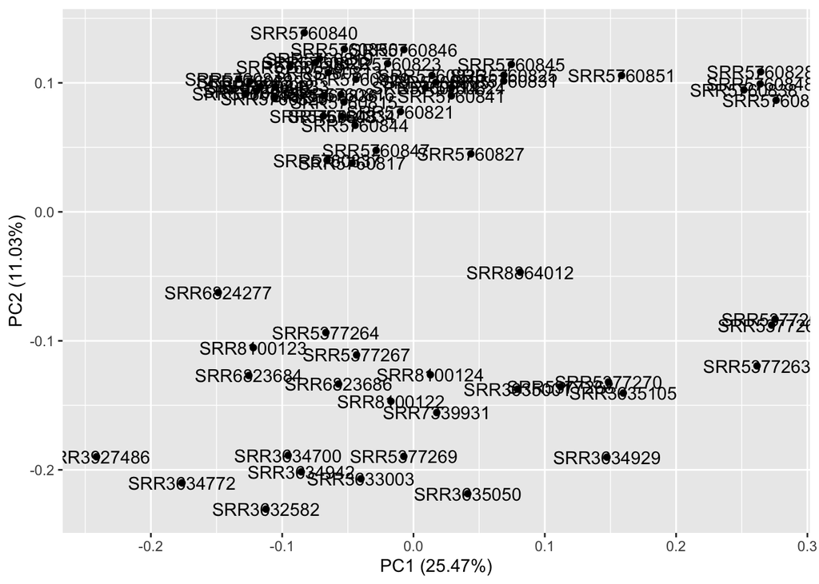

```r
#transpose final_gene_tpm, and transform (log10+0.000001)
final_gene_tpm_T<- transposeBigData(log10(final_gene_tpm + 0.000001))

#plot PCA, detect outlier libraries
autoplot(prcomp(final_gene_tpm_T), label = TRUE)
```

```r
#remove outlier libraries (by col)
for_modules <- final_gene_tpm %>% transposeBigData()
#%>% dplyr::select(-c("SRR5109825", "SRR5109827", "SRR533974" , "SRR3927496", "SRR8867385"))


saveRDS(for_modules, file = "/Users/nuriteliash/OneDrive - OIST/Repos/varroa-virus-networks-Local/results/for_modules.rds")

#OPTIONAL
#remove outlier libraries + significant interacting libraries (17), from the "module-covariate-reg" analysis
#sig_lib_17 <- c("SRR6823684", "SRR6824277", "SRR5760848","SRR5760838", "SRR5760828", "SRR5760818","SRR5377265", "SRR7339931","SRR5377270", "SRR5377269", "SRR5377268","SRR5377267",  "SRR5377266", "SRR5377265","SRR5377264","SRR5377263","SRR8864012")
#for_modules_49 <- final_gene_tpm %>% dplyr::select(-c("SRR5109825", "SRR5109827", "SRR533974" , "SRR3927496", "SRR8867385", "SRR6823684", "SRR6824277", "SRR5760848","SRR5760838", "SRR5760828", "SRR5760818","SRR5377265", "SRR7339931","SRR5377270", "SRR5377269", "SRR5377268","SRR5377267",  "SRR5377266", "SRR5377265","SRR5377264","SRR5377263","SRR8864012")) %>%transposeBigData()

#plot PCA - the reduced file
#autoplot(prcomp(transposeBigData(log10(for_modules + 0.000001))), label = TRUE)
```

### optional:PCA libraries by isoform

now the table is ready for varroa module making!

# following the 2.a step in WGCNA tutorial: “Automatic, one-step network construction and module detection”

### WGCNA set directory and library

```r
#=====================================================================================
#
#  Code chunk 1
#
#=====================================================================================

# If necessary, change the path below to the directory where the data files are stored.
setwd("/Users/nuriteliash/Documents/GitHub/varroa-virus-networks")
# Display the current working directory
getwd()

# Allow multi-threading within WGCNA. This helps speed up certain calculations.
options(stringsAsFactors = FALSE)
```

### 2.a.1 Choosing the soft-thresholding power: analysis of network topology

```r
#=====================================================================================
#
#  Code chunk 2
#
#=====================================================================================

# Choose a set of soft-thresholding powers
powers = c(c(1:10), seq(from = 12, to=25, by=2))
# Call the network topology analysis function
sft = pickSoftThreshold(for_modules, powerVector = powers, verbose = 5)
# Plot the results:
sizeGrWindow(9, 5)
par(mfrow = c(1,2));
cex1 = 0.9;
# Scale-free topology fit index as a function of the soft-thresholding power
plot(sft$fitIndices[,1], -sign(sft$fitIndices[,3])*sft$fitIndices[,2],
     xlab="Soft Threshold (power)",ylab="Scale Free Topology Model Fit,signed R^2",type="n",
     main = paste("Scale independence"));
text(sft$fitIndices[,1], -sign(sft$fitIndices[,3])*sft$fitIndices[,2],
     labels=powers,cex=cex1,col="red");
# this line corresponds to using an R^2 cut-off of h
abline(h=0.80,col="red")
# Mean connectivity as a function of the soft-thresholding power
plot(sft$fitIndices[,1], sft$fitIndices[,5],
     xlab="Soft Threshold (power)",ylab="Mean Connectivity", type="n",
     main = paste("Mean connectivity"))
text(sft$fitIndices[,1], sft$fitIndices[,5], labels=powers, cex=cex1,col="red")
```

### Constructing the gene network and identifying modules is now a simple function call:

```r
#=====================================================================================
#
#  Code chunk 3 - automatic!
#
#=====================================================================================

net = blockwiseModules(for_modules, power = 12,
                       TOMType = "unsigned", minModuleSize = 30,
                       reassignThreshold = 0, mergeCutHeight = 0.25,
                       numericLabels = TRUE, pamRespectsDendro = FALSE,
                       saveTOMs = TRUE,
                       saveTOMFileBase = "/Users/nuriteliash/OneDrive - OIST/Repos/varroa-virus-networks-Local/results/Varroa_modulesTOM",
                       verbose = 3)

# To see how many modules were identified and what the module sizes are, one can use table(net$colors). Its output is

table(net$colors)
```

[output not shown]

The hierarchical clustering dendrogram (tree) used for the module identification is returned in net$dendrograms[[1]]; The dendrogram can be displayed together with the color assignment using the following code

```r
#=====================================================================================
#
#  Code chunk 4 - automatic!
#
#=====================================================================================

# open a graphics window
sizeGrWindow(12, 9)
# Convert labels to colors for plotting
mergedColors = labels2colors(net$colors)
# Plot the dendrogram and the module colors underneath
plotDendroAndColors(net$dendrograms[[1]], mergedColors[net$blockGenes[[1]]],
                    "Module colors",
                    dendroLabels = FALSE, hang = 0.03,
                    addGuide = TRUE, guideHang = 0.05)
```

### chunk 5. save the module assignment and module eigengene information necessary for subsequent analysis:

all data saved to “/Users/nuriteliash/OneDrive - OIST/Repos/varroa-virus-networks-Local/results/”

```r
#=====================================================================================
#
#  Code chunk 5
#
#=====================================================================================

moduleLabels = net$colors
moduleColors = labels2colors(net$colors)
MEs = net$MEs;
geneTree = net$dendrograms[[1]];
save(MEs, moduleLabels, moduleColors, geneTree,
     file = "/Users/nuriteliash/OneDrive - OIST/Repos/varroa-virus-networks-Local/results/Varroa_modules_networkConstruction-auto.RData")
```

### Relating modules to external information and identifying important genes

prepare the “viralTraits” table (like the “clinicalTraits.csv”) of virus variables you wish to correlate to varroa modules

```r
# prepare the 'viruses_load' table, with 15 viruses,
# excluding viruses with tpm=zero for all libraries, in addition to viruses with very low levels, that appear in a few libraries: LSV, SBPV, KBV. So we are left with 15 of the initial 23 viruses

viruses_load <- read_rds("/Users/nuriteliash/OneDrive - OIST/Repos/varroa-virus-networks-Local/results/viruses_load.RData")

b_viruses_load <- viruses_load %>%
  # filter for specific viruses (15)
  filter(description %in% c("DWVa", "DWVc", "IAPV", "ABPV", "BQCV","SV", "VDV1/DWVb", "VDV2", "VDV3", "BMV", "ARV_2", "AmFV","VTLV","VDV4","VOV_1")) %>%
  column_to_rownames("description") %>%
  transposeBigData() %>%
  rownames_to_column("library") %>%
  #identify and remove the row numbers of the outlierd libraries (found by PCA)
  filter(!(library %in% c("SRR5109825", "SRR5109827", "SRR533974" , "SRR3927496", "SRR8867385"))) %>%
  column_to_rownames("library")

# The last step is to save the relevant expression and trait data for use in the next steps

# the varroa modules with the 'viralTraits' (total load and diversity)-
#chagne this fuke name to "1" or "2" once the viruse diversity will be reayd
#save(for_modules, viralTraits, file = "varroa_virus-01-dataInput.RData")

# the varroa modules with the 'viruses load' (15 viruses)
save(for_modules, b_viruses_load, file = "/Users/nuriteliash/OneDrive - OIST/Repos/varroa-virus-networks-Local/results/varroa_virus-01-dataInput.RData")

# also optional to remove another 16 outliered libraries:
#outLib_16 <- c("SRR6823684","SRR6824277","SRR5760848","SRR5760838","SRR5760828","SRR5760818","SRR7339931","SRR5377270","SRR5377269","SRR5377268","SRR5377267","SRR5377266","SRR5377265","SRR5377264","SRR5377263","SRR8864012")
```

now that we have a ‘viralTraits’ tables, we can associate it with the varroa modules we found earlier

i have saved the two files as in the tutorial: datTraits = “viralTraits”: traits in columns, libraries in rows datExpr = “for_modules” : varroa genes in columns, libraries in rows  
*note: in these files i have only 66 libraries, as we took 5 out after PCA

### WGCNA 3.a Quantifying module–trait associations

```r
#if you are starting from here,
# Load the expression and trait data saved in the first part
lnames <- load(file = "/Users/nuriteliash/OneDrive - OIST/Repos/varroa-virus-networks-Local/results/varroa_virus-01-dataInput.RData");

#The variable lnames contains the names of loaded variables.
lnames

# Load network data saved in the second part.
lnames = load(file = "/Users/nuriteliash/OneDrive - OIST/Repos/varroa-virus-networks-Local/results/Varroa_modules_networkConstruction-auto.RData");
lnames

# Define numbers of genes and samples
nGenes = ncol(for_modules);
nSamples = nrow(for_modules);
# Recalculate MEs with color labels
MEs0 = moduleEigengenes(for_modules, moduleColors)$eigengenes
MEs = orderMEs(MEs0)

# correlate the modules eigengenes (MEs) with the viral load (b_viruses_load)
moduleTraitCor = cor(MEs, b_viruses_load, use = "p");
moduleTraitPvalue = corPvalueStudent(moduleTraitCor, nSamples)

### Controlling the false discovery rate: Benjamini–Hochberg procedure ###
# using p.adjust function, for all comparisons, 15 modules and 15 viruses (m=225).

# first make the p-value matrix into a dataframe
moduleTraitPvalue_0 <- as.data.frame(moduleTraitPvalue)

# then "gather" all the p-values, so they will apear in one column
longer_Pvalue <- moduleTraitPvalue_0 %>%
  rownames_to_column("module") %>%
  gather("virus", "pvalue", -module)

# now calculate the p.adjust for each p-value
Padjust <- p.adjust(longer_Pvalue$pvalue, method = "fdr")

# and add the column of adjusted pvalues
Padjust <- add_column(longer_Pvalue, Padjust)

# now spread it back
moduleTraitPadjust <- Padjust %>%
  dplyr::select(-pvalue) %>%
  group_by(virus) %>%
  pivot_wider(names_from = virus, values_from = Padjust)
moduleTraitPadjust <- column_to_rownames(moduleTraitPadjust, "module")

# before correlating, make the two dataframes into "matrixes"
moduleTraitCor_66 <- as.matrix(moduleTraitCor)
moduleTraitPadjust_66 <- as.matrix(moduleTraitPadjust)

# save the matrices for next analysis
save(moduleTraitCor_66,moduleTraitPadjust_66, file = "/Users/nuriteliash/OneDrive - OIST/Repos/varroa-virus-networks-Local/results/moduleTraitCor_66.RData")
```

# Can we predict the virus-varroa interaction given the virus abundance?

mantel.test: the correlation btw two matrices

```r
# x: how virus interacts with varroa expression, and y: the correlation of viral abundance across samples}

# load the two matrices:
# the module–trait association matrix
names <- load(file = "/Users/nuriteliash/OneDrive - OIST/Repos/varroa-virus-networks-Local/results/moduleTraitCor_66.RData");
names
# and the viral abundance correlogram
names <- load(file = "/Users/nuriteliash/OneDrive - OIST/Repos/varroa-virus-networks-Local/results/virusAbundCor_66.RData");
names

# make corleation matrix of the "moduleTraitCor":
corModulTrait_66 <- cor(moduleTraitCor_66)

# (1) Mantel test using "ape" library:
mantel.test(corModulTrait_66, virusAbundCor_66, graph = TRUE,
            main = "Mantel test",
            xlab = "z-statistic", ylab = "Density",
            sub = "The vertical line shows the observed z-statistic")

# (2) Mantel test using "vegan" library:
mantel(corModulTrait_66, virusAbundCor_66, method="pearson", permutations=1000)
```

### WGCNA 3.a Quantifying module–trait associations

```r
sizeGrWindow(10,6)
# Will display correlations and their p-values
textMatrix = paste(signif(moduleTraitCor_66, 2), "\n(",
                   signif(moduleTraitPadjust_66, 1), ")", sep = "");
dim(textMatrix) = dim(moduleTraitCor_66)
par(mar = c(6, 8.5, 3, 3));
# Display the correlation values within a heatmap plot
labeledHeatmap(Matrix = moduleTraitCor_66,
               xLabels = names(b_viruses_load),
               yLabels = names(MEs),
               ySymbols = names(MEs),
               colorLabels = FALSE,
               colors = blueWhiteRed(50),
               textMatrix = textMatrix,
               setStdMargins = FALSE,
               cex.text = 0.7,
               zlim = c(-1,1),
               main = paste("Varroa Module-viruses relationships"))
```

#### hirarchial clustering of the viruses, based to their correlation to the varroa modules

```r
#plot hirarchial clustering of the viruses, based to their correlation to the varroa modules.
plot(hclust(dist(abs(transposeBigData(moduleTraitCor)))))
```

We quantify associations of individual genes with our trait of interest (viral load) by defining Gene Significance GS as (the absolute value of) the correlation between the gene and the trait. For each module, we also define a quantitative measure of module membership MM as the correlation of the module eigengene and the gene expression profile. This allows us to quantify the similarity of all genes on the array to every module.

### WGCNA 3.b Gene relationship to trait and important modules: Gene Significance and Module Membership

```r
# Define numbers of genes and samples
nGenes = ncol(for_modules);
nSamples = nrow(for_modules);
# Recalculate MEs with color labels
MEs0 = moduleEigengenes(for_modules, moduleColors)$eigengenes
MEs = orderMEs(MEs0)

# names (colors) of the modules
modNames = substring(names(MEs), 3)
virusNames = substring(names(b_viruses_load), 1)

#make a table of the Module-membership ("MM") of each gene (which is its correlation coefficient, pearson)
geneModuleMembership_66 = as.data.frame(cor(for_modules, MEs, use = "p"));
MMPvalue_66 = as.data.frame(corPvalueStudent(as.matrix(geneModuleMembership_66), nSamples));

### Controlling the false discovery rate: Benjamini–Hochberg procedure ###
# using p.adjust function, for all comparisons, 15 modules and 15 viruses (m=225).

# first make the p-value matrix into a dataframe
MMPvalue_66_0 <- as.data.frame(MMPvalue_66)

# then "gather" all the p-values, so they will apear in one column
longer_Pvalue <- MMPvalue_66_0 %>%
    rownames_to_column("module") %>%
    gather("virus", "pvalue", -module)

# now calculate the p.adjust for each p-value
Padjust <- p.adjust(longer_Pvalue$pvalue, method = "fdr")

# and add the column of adjusted pvalues
Padjust <- add_column(longer_Pvalue, Padjust)

# now spread it back
MMPadjust_66 <- Padjust %>%
    dplyr::select(-pvalue) %>%
    group_by(virus) %>%
    pivot_wider(names_from = virus, values_from = Padjust)
MMPadjust_66 <- column_to_rownames(MMPadjust_66, "module")

#change the name of the columns to start with "MM" then the module name
names(geneModuleMembership_66) = paste("MM", modNames, sep="");
names(MMPadjust_66) = paste("padj.MM", modNames, sep="");

### now the same for Trait-significance ("GS"):
# make a table with the Trait-significance ("GS") for each gene (which is its correlation coefficient, pearson)
geneTraitSignificance_66 = as.data.frame(cor(for_modules, b_viruses_load, use = "p"));
GSPvalue_66 = as.data.frame(corPvalueStudent(as.matrix(geneTraitSignificance_66), nSamples));

  ### Controlling the false discovery rate: Benjamini–Hochberg procedure ###
# using p.adjust function, for all comparisons, 15 modules and 15 viruses (m=225).

# first make the p-value matrix into a dataframe
GSPvalue_66_0 <- as.data.frame(GSPvalue_66)

# then "gather" all the p-values, so they will apear in one column
longer_Pvalue <- GSPvalue_66_0 %>%
    rownames_to_column("module") %>%
    gather("virus", "pvalue", -module)

# now calculate the p.adjust for each p-value
Padjust <- p.adjust(longer_Pvalue$pvalue, method = "fdr")

# and add the column of adjusted pvalues
Padjust <- add_column(longer_Pvalue, Padjust)

# now spread it back
GSPadjust_66 <- Padjust %>%
    dplyr::select(-pvalue) %>%
    group_by(virus) %>%
    pivot_wider(names_from = virus, values_from = Padjust)
GSPadjust_66 <- column_to_rownames(GSPadjust_66, "module")

#rename the col names by adding the initial "GS." for genesignificance, and "p.GS." for p-value.
names(geneTraitSignificance_66) = paste("GS.", names(b_viruses_load), sep="");
names(GSPadjust_66) = paste("pdj.GS.", names(b_viruses_load), sep="");

#save data:
save(geneTraitSignificance_66, GSPadjust_66, geneModuleMembership_66, MMPadjust_66, file = "/Users/nuriteliash/OneDrive - OIST/Repos/varroa-virus-networks-Local/results/geneTraitANDgeneMM_66.RData")
```

the following verboseScatterplot plots the Varroa genes, based on the correlation between: - their MM value (geneModuleMembership), against - their GS value (geneTraitSignificance).

to get the interaction of each module, against each virus, just change the “module” and “virus” at the beginning of the code.

### WGCNA 3.c Intramodular analysis: identifying genes with high GS and MM

```r
sizeGrWindow(8,6)
par(mfrow=c(2,2))
module = "magenta"
virus = "VDV2"
column = match(module, modNames);
column1 = match(virus, virusNames);
moduleGenes = moduleColors==module;
verboseScatterplot(geneModuleMembership_66[moduleGenes, column],
                   abs(geneTraitSignificance_66[moduleGenes, column1]),
                   xlab = paste("Module Membership in", module, "module"),
                   ylab = paste("Gene Trait significance for" ,virus, "viral load"),
                   main = paste(module, "Module membership vs. gene", virus, "significance\n 66 libraries; "),
                   cex.main = 1.2, cex.lab = 1.2, cex.axis = 1.2, col = module)
module = "magenta"
virus = "DWVa"
column = match(module, modNames);
column1 = match(virus, virusNames);
moduleGenes = moduleColors==module;
verboseScatterplot(abs(geneModuleMembership_66[moduleGenes, column]),
                   abs(geneTraitSignificance_66[moduleGenes, column1]),
                   xlab = paste("Module Membership in", module, "module"),
                   ylab = paste("Gene Trait significance for" ,virus, "viral load"),
                   main = paste(module, "Module membership vs. gene", virus, "significance\n 66 libraries; "),
                   cex.main = 1.2, cex.lab = 1.2, cex.axis = 1.2, col = module)
module = "magenta"
virus = "ARV_2"
column = match(module, modNames);
column1 = match(virus, virusNames);
moduleGenes = moduleColors==module;
verboseScatterplot(abs(geneModuleMembership_66[moduleGenes, column]),
                   abs(geneTraitSignificance_66[moduleGenes, column1]),
                   xlab = paste("Module Membership in", module, "module"),
                   ylab = paste("Gene Trait significance for" ,virus, "viral load"),
                   main = paste(module, "Module membership vs. gene", virus, "significance\n 66 libraries; "),
                   cex.main = 1.2, cex.lab = 1.2, cex.axis = 1.2, col = module)
```

as intramodular connectivity (KIn) and module membership (MM) are positivly and linearly correlated, similarly, we can plot the interaction of the geneTraitSignificance to the intramodular connectivity for each gene.

## 7. Module membership, intramodular connectivity and screening for intramodular hub genes

[link for the tutorial](https://horvath.genetics.ucla.edu/html/CoexpressionNetwork/Rpackages/WGCNA/Tutorials/Simulated-07-Membership.pdf) ### 7.a Intramodular connectivity

```r
# We begin by calculating the intramodular connectivity for each gene. (In network literature, connectivity is often referred to as ”degree”.) The function intramodularConnectivity computes the whole network connectivity kTotal, the within module connectivity kWithin, kOut=kTotal-kWithin, and kDiff=kIn-kOut=2*kIN-kTotal

# calculate the correlation between each pair of genes
ADJ1_66 <- abs(cor(for_modules,use="p"))^6
# compute the different degrees of connectivity:
Alldegrees1_66 <- intramodularConnectivity(ADJ1_66, moduleColors)
head(Alldegrees1_66)

#save it
save(Alldegrees1_66, file = "/Users/nuriteliash/OneDrive - OIST/Repos/varroa-virus-networks-Local/results/IntraModCon66.RData")
```

### 7.b Relationship between gene significance and intramodular connectivity

```r
#We plot the geneTraitSignificance (gene-virus correlation) against intramodular connectivity (kWithin), *per virus*:
colorlevels=unique(moduleColors)
sizeGrWindow(9,6)
par(mfrow=c(2,as.integer(0.5+length(colorlevels)/2)))
par(mar = c(4,5,3,1))
for (i in c(1:length(colorlevels)))
{
  whichmodule=colorlevels[[i]];
  restrict1 = (moduleColors==whichmodule);
  verboseScatterplot(Alldegrees1_66$kWithin[restrict1],
                     geneTraitSignificance_66$GS.VDV2[restrict1], col=moduleColors[restrict1],
                     main=whichmodule,
                     xlab = "Connectivity", ylab = "Gene Significance", abline = TRUE)
}
```

### 7.c Generalizing intramodular connectivity for all genes on the array (module membership)

The intramodular connectivity measure is only defined for the genes inside a given module. But in practice it can be very important to measure how connected a given genes is to biologically interesting modules (that are not necessary this gene module) The module-membership is a generalized intramodular connectivity for all genes on the array

```r
# We define a data frame containing the module membership (MM) values for each module. In the past, we called the module membership values kME.
datKME=signedKME(for_modules, MEs, outputColumnName="MM.")
# Display the first few rows of the data frame
head(datKME)

#We have a module membership value for each gene in ALL modules
```

### 7.d Finding genes with high gene significance and high intramodular connectivity in interesting modules

we wish to filter out genes with: 1. high module connectivity / membership 2. significant correlation with viral load (specific viruses)

```r
#simple code for one module-virus interaction:
#FilterGenes= abs(geneTraitSignificance$GS.DWVa)> .2 & abs(datKME$MM.magenta)>.8
#table(FilterGenes)
#dimnames(data.frame(for_modules))[[2]][FilterGenes]

#but we want to look at all possible interactions, so we make a function:
# we make a function "filterGenes" to filter for the first most significant hub-genes in each module-virus pair:
  filterGenes <- function(vload.tbl, datKME, genes, virus.col.name, module.name) {
    GS_virus <- as.numeric(cor(vload.tbl[,virus.col.name],genes, use="p"))
    FilterGenes <- abs(GS_virus) > 0.2 & abs(datKME[,module.name]) > 0.45
    inds <- which(FilterGenes == TRUE)
    #Which genes were filtered in?
    genes <- colnames(genes)[inds]
    #What are their connectivity coefficient?
    con <- datKME[,module.name][inds]
    #What are their virus-correlation coefficient?
    virus_coef <- GS_virus[inds]
    # sort the genes in descending order, according to the absolute value of the connectivity
    abs.con <- abs(con)
    hub <- data.frame(genes,con,abs.con,virus_coef)
    hub <- hub[order(hub$abs.con, decreasing = TRUE),]
    # take the first 50 hubgenes
    #hub <- hub[0:50,]
    #hub <- select(.data = hub, -abs.con)
    return(hub)
  }

# now we can run it for each virus-module pair (indexed as "i" and "j" respectievly),

# assign the files to the sequences in the for-loop
viruses <- colnames(b_viruses_load)
modules <- colnames(datKME)
# we make a list, in which the tables will be saved
ls.66 <- list()

for (i in 1:length(viruses)) {
  for (j in 1:length(modules)) {
    ls.name <- paste(viruses[i], modules[j], sep = "_")
    ls.66[[ls.name]] <- filterGenes(b_viruses_load, datKME, for_modules, viruses[i], modules[j])
    ls.66[[ls.name]]$virus <- viruses[i]
    ls.66[[ls.name]]$module <- modules[j]
    ls.66[[ls.name]] <- na.omit(ls.66[[ls.name]])
    cat(ls.name, " is done!\n")
  }
}

hist(sapply(ls.66, nrow))

ls.66.tbl <- bind_rows(ls.66)
q=sapply(ls.66, function(x) sum(is.na(x)))
sum(q > 0)

#save the list as RData in the local folder fo later overlapping:
save(ls.66.tbl, ls.66, file = "/Users/nuriteliash/OneDrive - OIST/Repos/varroa-virus-networks-Local/results/HubGenes_66.RData")
```

### 7.e Relationship between the module membership measures (e.g. MM.magenta) and intramodular connectivity

```r
#We now explore the relationship between the module membership measures (e.g. MM.magenta) and intramodular connectivity
# this is an important check to see that the data are ok = that there is a linear correlation between the two measures
sizeGrWindow(8,6)
par(mfrow=c(2,2))
# We choose 4 modules to plot: magenta, red, salmon, brown
# For simplicity we write the code out explicitly for each module.
which.color="magenta";
restrictGenes=moduleColors==which.color
verboseScatterplot(Alldegrees1_66$kWithin[ restrictGenes],
                   (datKME[restrictGenes, paste("MM.", which.color, sep="")])^6,
                   col=which.color,
                   xlab="Intramodular Connectivity",
                   ylab="(Module Membership)^6")

which.color="red";
restrictGenes=moduleColors==which.color
verboseScatterplot(Alldegrees1_66$kWithin[ restrictGenes],
                   (datKME[restrictGenes, paste("MM.", which.color, sep="")])^6,
                   col=which.color,
                   xlab="Intramodular Connectivity",
                   ylab="(Module Membership)^6")

which.color="salmon";
restrictGenes=moduleColors==which.color
verboseScatterplot(Alldegrees1_66$kWithin[ restrictGenes],
                   (datKME[restrictGenes, paste("MM.", which.color, sep="")])^6,
                   col=which.color,
                   xlab="Intramodular Connectivity",
                   ylab="(Module Membership)^6")

which.color="brown";
restrictGenes=moduleColors==which.color
verboseScatterplot(Alldegrees1_66$kWithin[ restrictGenes],
                   (datKME[restrictGenes, paste("MM.", which.color, sep="")])^6,
                   col=which.color,
                   xlab="Intramodular Connectivity",
                   ylab="(Module Membership)^6")
```